# Lesson 04 - Intro to R Markdown

Last Updated 08-28-2019

# Introduction

In this lesson you will learn to write a document using R markdown, integrate live R code into a literate statistical program, compile R markdown documents using `knitr` and related tools, and organize a data analysis sandbox so that it is reproducible and accessible to others.

### Learning Objectives

After completing this lesson learners will be able to create a new R markdown document, identify the components of a R Markdown document, and explain how R markdown files facilitates sharing of reproducible research.

### Pre-requisites

- Have R and R Studio installed
- Have the following packages installed: `rmarkdown`, `knitr`

# Document structure

R Markdown is an example of literate programming where the explanation of the program (or analysis) logic is presented in a natural language (such as English), with supporting pieces of code embedded in the document itself. R Markdown combines normal text such as this sentence, code and the output from the code all in one Rmarkdown (`.Rmd`) file.

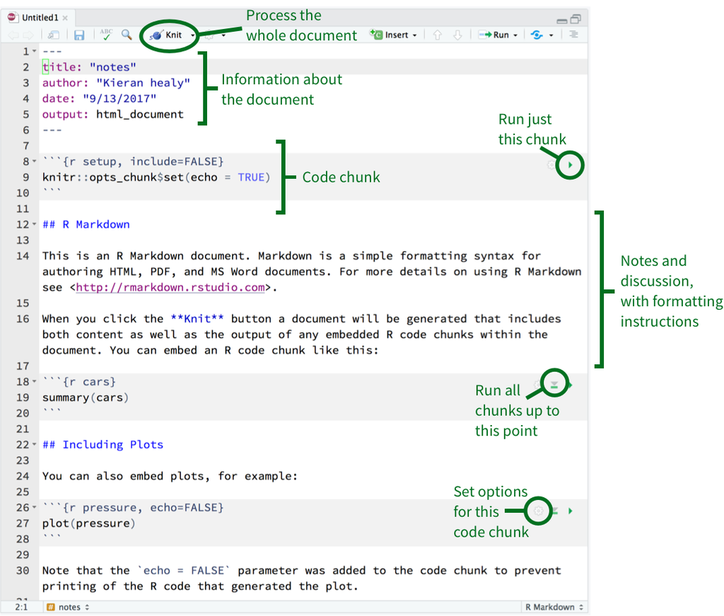

Components of a markdown document

*Image credit: Data Visualization by Kieran Healy. Available at http://socviz.co/*

Code chunks start with three back ticks (to the left of the 1) and an r in braces. Chunks close (end) with another three back ticks. Note the background color of this section has changed to a different shade. This helps you identify you have closed your code chunk properly.

You can insert code chunks by using the button in the top right of an RMD file (Insert –> R), or by typing `CTRL`+`ALT`+`I`.

Only code goes in code chunks. That’s why they’re called **code** chunks. No normal text. All explanatory text goes outside a code chunk.

# Test your setup

Let’s create your first markdown file!

1. In R Studio go to *File* –> *New File* –> *R Markdown*
2. Title this document **My First R Markdown Document**, then click OK.
3. Click the small blue disk icon to save this file into your class folder.
4. Save this file using the file name **test_markdown_document**.
   - File names cannot have spaces or special characters.
   - Do not specify the file type. It will be set automatically.
5. Click the **KNIT** button (has the yarn ball next to it) to convert this file into HTML.
6. Look at the HTML file that was created. You should be able to match the code with the resulting output.

This is what we mean by reproducible. If you make a change in the code document, and re-knit (aka compile), your changes will be reflected in the generated document.

# Make a change

Play around with modifying the text and the R code.

1. Change the code from `summary(cars)` to `summary(iris)`.
2. Write a sentence below this code chunk. It could be “Hello world”.
3. Add a code chunk and type the equation `2+2` in the code chunk.
4. Re-knit this document and observe your changes.

You are now ready to start the first assignment.

# Start Assignment 1

1. **Right click** and select **save as** (or save target as) to download [HW 1.Rmd] code file to your class folder.
2. Navigate to your class folder and double click to open this file in R Studio
   - You might have to tell your computer what program to use.
   - Do NOT open this file from your browser window.
3. Double click on this file (from your class folder) to open it in R studio.
4. This `.Rmd` file is a template for you to use to write your assignment. Write your answers directly into this document.
5. After you answer each question, knit the file to ensure that your work is saved, and that your answers are being correctly displayed in the final document.

# Additional Resources

- Intro to R Markdown by R Studio (1 minute video): “[What is R Markdown?](http://rmarkdown.rstudio.com/lesson-1.html)”
  - Relevant portions in this tutorial are “How it works”, “Code Chunks”, and “Output Formats”
- Gallery of the vast range of output and product types that you can create using R Markdown including PDF reports, interactive dashboards, maps, webpages like this one and more: https://rmarkdown.rstudio.com/gallery.html